# HW_4

```python
import numpy as np
import matplotlib
import matplotlib.pyplot as plt
import scipy
from scipy import stats
import pandas as pd
```

## Homework 4

The purpose of this homework is to get used to plotting and examining subsets of data. In the next lab we will have 25 million data points. And big instruments produce data at even more fantastic rates—our telescope in western Australia produces a billion data values per second, and we're hoping to upgrade it to produce at least an order of magnitude more.

You don't want to plot millions to billions of points on a plot, it will look like a blob and take forever. So we need to practice looking at subsets of the data.

### Problem 0: some fake data to mess with

So let's start by making some fake background data.

First, let's make a time axis that goes from 0 to 100 π in 1e5 steps

```
t = np.linspace(0,np.pi*100,np.int(1e5))
```

Then an offset sinusoid

```
N = 10+np.sin(t)
```

Then some random background data whose mean and variance depend on N

```
bkgd = stats.norm.rvs(size=np.int(1e5))*np.sqrt(N)+N
```

Now this is small enough at only 100,000 points that you can plot it, but it is messy and not very informative.

```python
t = np.linspace(0,np.pi*100,int(1e5))
N = 10+np.sin(t)
bkgd = stats.norm.rvs(size=int(1e5))*np.sqrt(N)+N
t[2000]
```

```
6.283248139660984
```

### Problem 2: density

Now you can make a scatter plot of just a 100,000 points, so you might try it to see what it looks like. But particularly in the central areas the points all overlap into just a blob, and this just gets worse as the number of points goes up. What is better is to plot the density of the points. There are several ways of doing this, but a 2D histogram plot is the easiest (plt.hist2d() in python and histogram2() in MatLab).

2a) Make a 2d histogram plot. Read about options, and play with binsize so it is useful (too large a bin and everything washes out, too small and the sample noise dominates). Make sure you use a colorbar.

2b) Clearly explain what is being plotted in your plot (e.g. what does each color mean?)

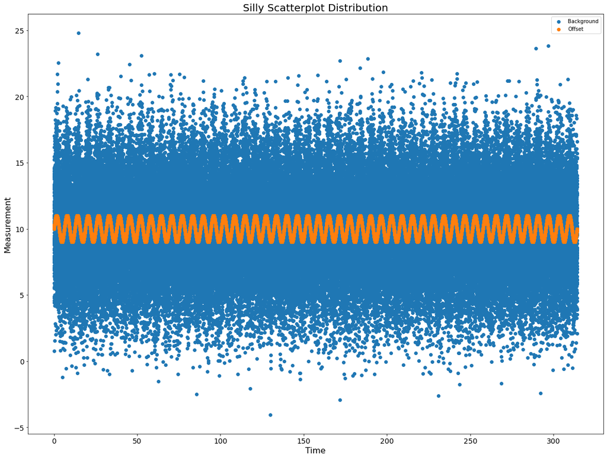

```python
fig, ax = plt.subplots(1, 1)
plt.tick_params(labelsize = 14)
plt.scatter(t, bkgd, label='Background')
plt.scatter(t, N, label='Offset')
plt.xlabel('Time', size=16)
plt.ylabel('Measurement', size=16)
plt.title('Silly Scatterplot Distribution', size=20)
plt.legend()
plt.show()
```

Above is proof that scatterplots do not work for this amount of data!

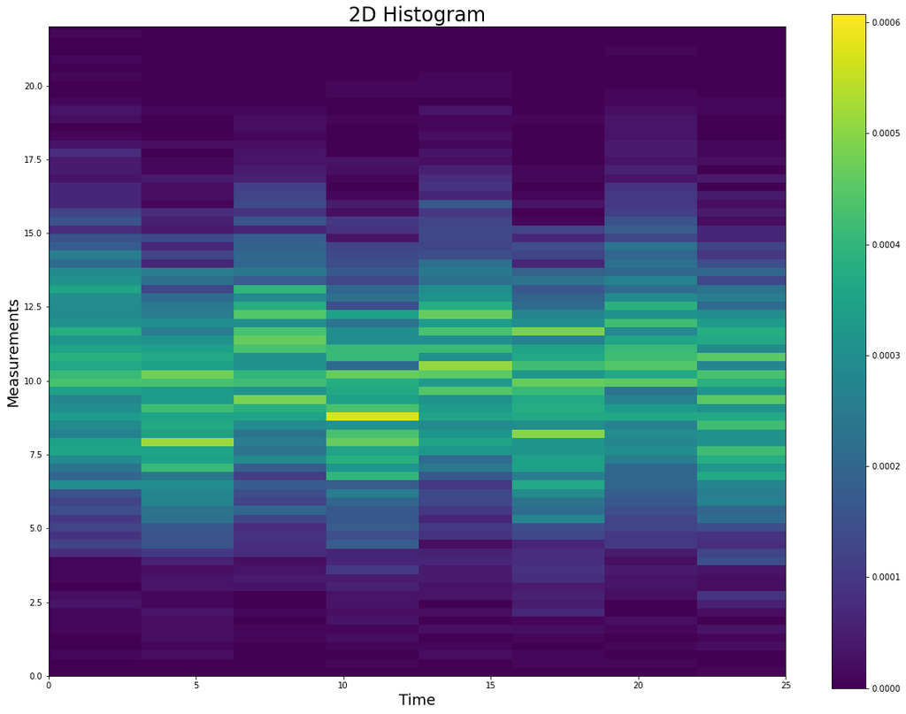

```python
plt.rcParams["figure.figsize"] = (20,15)
a = np.vstack((N,bkgd))
a.shape
fig, ax = plt.subplots(1, 1)
h1 = ax.hist2d(t,a[0,:],bins=100, density=True);
h2 = ax.hist2d(t,a[1,:],bins=100, density=True);
ax.set_aspect('equal', 'box')
plt.xlim([0, 25])
plt.ylim([0, 22])
plt.title("2D Histogram", fontsize = 24)
plt.ylabel("Measurements", fontsize = 18)
plt.xlabel("Time", fontsize = 18)
plt.colorbar(h2[3], ax=ax)
```

The plot above is a 2D distribution of the density of each possible measurement per unit time according to the two distribution patterns we created earlier. Color indicates incidence, with darker colors indicating a smaller incidence of that particular measurement at that timestamp, and brighter colors indicating a higher incidence of that measurement at the given time it corresponds to.

## Problem 3: folding

Now if you have a periodic signal, it is possible to fold the data stream at that period to make the pattern clearer.

3a) Make an new time variable that folds at a period of 2π (the modulo operator is your friend, variably expressed as mod(), %, or rem()). Then make a scatter plot of all your data, but now folded. (Reminder, for more data you'd never actually want to plot all the points.)

```python
N_f = np.empty([1,2000])
bkgd_f = np.empty([1,2000])

for i in range(0,100000):
    mod = t[i]%2*np.pi

    if mod<=0.0002:
        new_row_N = N[i:(i+2000)]
        new_row_bkgd = bkgd[i:(i+2000)]
        N_f = np.append(N_f,[new_row_N],axis=0)
        bkgd_f = np.append(bkgd_f,[new_row_bkgd],axis=0)
    else:
        N_f = N_f
        bkgd_f = bkgd_f

print(N_f.shape)
print(bkgd_f.shape)
```

```
(5, 2000)
(5, 2000)
```

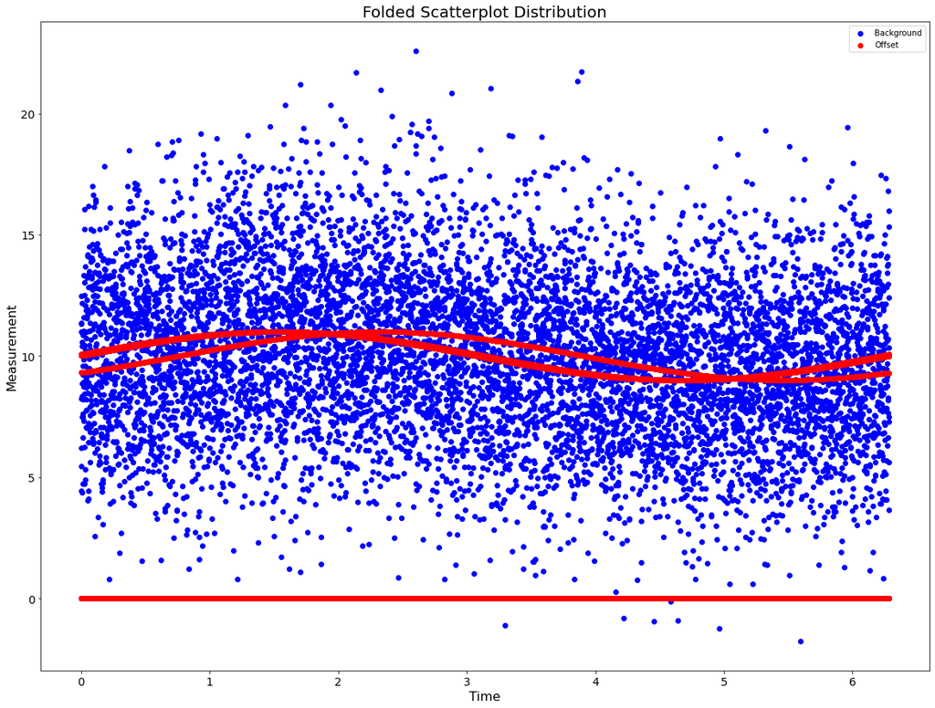

```python
fig, ax = plt.subplots(1, 1)
plt.tick_params(labelsize = 14)
t_f = np.linspace(0,np.pi*2,int(2000))
plt.scatter(t_f, bkgd_f[0,:], color='b', label='Background')
plt.scatter(t_f, bkgd_f[1,:], color='b')
plt.scatter(t_f, bkgd_f[2,:], color='b')
plt.scatter(t_f, bkgd_f[3,:], color='b')
plt.scatter(t_f, bkgd_f[4,:], color='b')
plt.scatter(t_f, N_f[0,:], color='r', label='Offset')
plt.scatter(t_f, N_f[1,:], color='r')
plt.scatter(t_f, N_f[2,:], color='r')
plt.scatter(t_f, N_f[3,:], color='r')
plt.scatter(t_f, N_f[4,:], color='r')
plt.xlabel('Time', size=16)
plt.ylabel('Measurement', size=16)
plt.title('Folded Scatterplot Distribution', size=20)
plt.legend()
plt.show()
```

3b) Make a 2D histogram plot of your folded data.

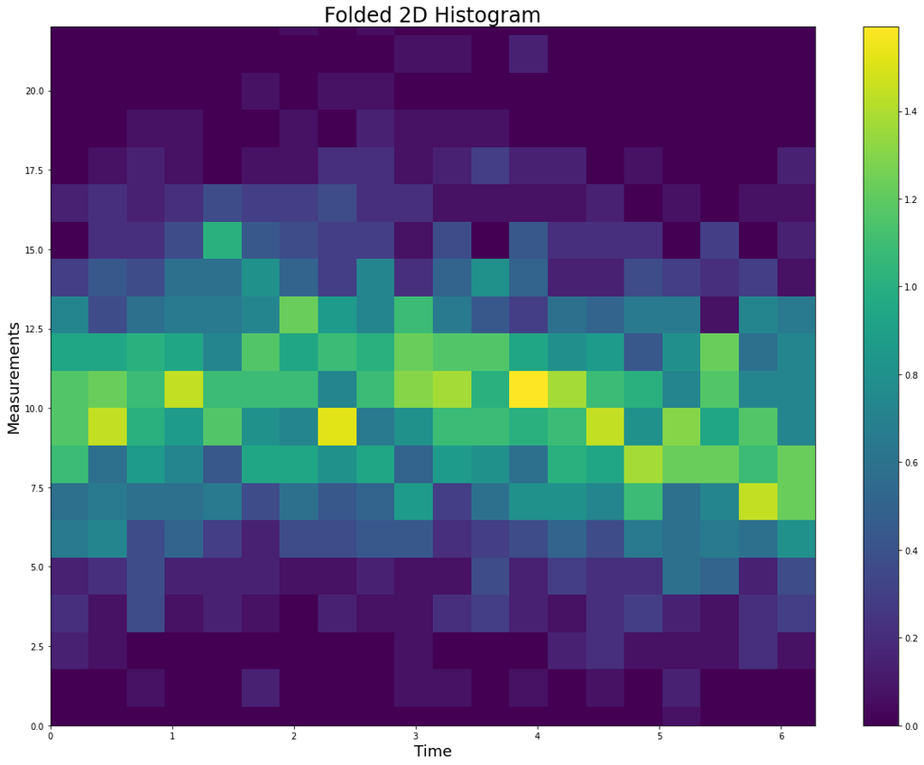

```python
plt.rcParams["figure.figsize"] = (20,15)
#a = np.vstack((N,bkgd))
#a.shape
fig, ax = plt.subplots(1, 1)

h1 = ax.hist2d(t_f,N_f[0,:],bins=20, density=True);
h2 = ax.hist2d(t_f,N_f[1,:],bins=20, density=True);
h3 = ax.hist2d(t_f,N_f[2,:],bins=20, density=True);
h4 = ax.hist2d(t_f,N_f[3,:],bins=20, density=True);
h5 = ax.hist2d(t_f,N_f[4,:],bins=20, density=True);

h7 = ax.hist2d(t_f,bkgd_f[0,:],bins=20, density=True);
h8 = ax.hist2d(t_f,bkgd_f[1,:],bins=20, density=True);
h9 = ax.hist2d(t_f,bkgd_f[2,:],bins=20, density=True);
h10 = ax.hist2d(t_f,bkgd_f[3,:],bins=20, density=True);
h11 = ax.hist2d(t_f,bkgd_f[4,:],bins=20, density=True);

#ax.set_aspect('equal', 'box')
plt.xlim([0, 2*np.pi])
plt.ylim([0, 22])
plt.title("Folded 2D Histogram", fontsize = 24)
plt.ylabel("Measurements", fontsize = 18)
plt.xlabel("Time", fontsize = 18)
plt.colorbar(h2[3], ax=ax)
```

Optional, but very fun and useful:

3c) You can use 2D histograms or digitize functions, plus some math, to calculate the average as a function of the folded variable. You can then overplot this on 3b to show the average as a function of folded time.